# 《R语言》第9章：回归分析

[返回课程主页](https://psychbruce.github.io/RCourse/)

授课教师：包寒吴霜

版权声明：本套课程材料开源，使用和分享必须遵守「创作共用许可协议 CC BY-NC-SA」（来源引用-非商业用途使用-以相同方式共享）。

# Chap09：回归分析

#### 往期要点回顾

- [Chap08 # 多因素方差分析](https://psychbruce.github.io/RCourse/Chap08#%E5%A4%9A%E5%9B%A0%E7%B4%A0%E6%96%B9%E5%B7%AE%E5%88%86%E6%9E%90)
- [Chap08 # 简单效应检验与多重比较](https://psychbruce.github.io/RCourse/Chap08#%E7%AE%80%E5%8D%95%E6%95%88%E5%BA%94%E6%A3%80%E9%AA%8C%E4%B8%8E%E5%A4%9A%E9%87%8D%E6%AF%94%E8%BE%83)

#### 本章要点目录

- 【知识点】回归分析（regression）统计术语
- 【实践1】截距模型
- 【实践2】一元回归模型
- 【实践3】多元回归模型
- 【实践4】交互作用模型（重点）
- 【知识点】为什么回归分析交互作用中的斜率并不是“主效应”？（重点）
- 【实践5】如何让回归分析交互作用中的斜率具有“主效应”含义？
- 【实践6】多元回归模型的结果表输出（重点）
- 【实践7】空气质量数据回归分析实例
- 【实践8】基于PROCESS()函数的调节效应与简单斜率分析（重点）
- 【知识点】回归模型的基本假定
- 【实践9】检查回归模型是否满足基本假定
- 【探索发现】各类回归模型使用的R函数

```r
## 本章所需R包
library(bruceR)  # 回归模型结果的 Word 表格输出
library(sjPlot)  # 回归模型结果的 HTML 表格输出
```

# 回归分析的统计知识回顾

#### 【知识点】回归分析（regression）统计术语

多元回归模型的一般形式：

$$Y_i = b_0 + b_1 X_1 + b_2 X_2 + ... +
b_p X_p + e_i$$

- **截距（intercept）**
  - $b_0$：所有自变量都取0时，因变量的预测期望值
    - 如果没有任何自变量，截距就是因变量的平均值
- **斜率（slope）**
  - $b_1$, …, $b_p$：自变量每变化1，因变量变化多少个单位
    - 非标准化系数：$b$
    - 标准化系数：$\beta$
- **残差（residual）**
  - $e_i = Y_i - \hat{Y_i}$：每个个体（$i$）因变量的真实观测值（$Y_i$）与模型预测值（$\hat{Y_i}$）之间的差异

# 回归模型建立与结果报告

```r
## 数据准备
data = data.table(
  A = c(0, 0, 0,  0, 0, 0,  1, 1, 1,  1, 1, 1),
  B = c(0, 0, 0,  1, 1, 1,  0, 0, 0,  1, 1, 1),
  Y = c(0, 1, 2,  3, 4, 5,  0, 1, 2,  6, 7, 8)
)
data
```

```
        A     B     Y
    <num> <num> <num>
 1:     0     0     0
 2:     0     0     1
 3:     0     0     2
 4:     0     1     3
 5:     0     1     4
 6:     0     1     5
 7:     1     0     0
 8:     1     0     1
 9:     1     0     2
10:     1     1     6
11:     1     1     7
12:     1     1     8
```

表1. 原始数据

| 原始数据 | B0条件 | B1条件 |
| --- | --- | --- |
| **A0条件** | 0, 1, 2 | 3, 4, 5 |
| **A1条件** | 0, 1, 2 | 6, 7, 8 |

表2. A和B的条件均值与边际均值

| 均值 | B0条件均值 | B1条件均值 | 边际均值 |
| --- | --- | --- | --- |
| **A0条件均值** | **1.00** | **4.00** | 2.50 |
| **A1条件均值** | **1.00** | **7.00** | 4.00 |
| **边际均值** | 1.00 | 5.50 | 3.25 |

```r
## 方差分析
m = MANOVA(data, dv="Y", between=c("A", "B"))
```

```
====== ANOVA (Between-Subjects Design) ======

Descriptives:
────────────────────────
 "A" "B"  Mean    S.D. n
────────────────────────
  A0  B0 1.000 (1.000) 3
  A0  B1 4.000 (1.000) 3
  A1  B0 1.000 (1.000) 3
  A1  B1 7.000 (1.000) 3
────────────────────────
Total sample size: N = 12

ANOVA Table:
Dependent variable(s):      Y
Between-subjects factor(s): A, B
Within-subjects factor(s):  –
Covariate(s):               –
─────────────────────────────────────────────────────────────────────
           MS   MSE df1 df2      F     p     η²p [90% CI of η²p]  η²G
─────────────────────────────────────────────────────────────────────
A       6.750 1.000   1   8  6.750  .032 *     .458 [.034, .715] .458
B      60.750 1.000   1   8 60.750 <.001 ***   .884 [.680, .940] .884
A * B   6.750 1.000   1   8  6.750  .032 *     .458 [.034, .715] .458
─────────────────────────────────────────────────────────────────────
MSE = mean square error (the residual variance of the linear model)
η²p = partial eta-squared = SS / (SS + SSE) = F * df1 / (F * df1 + df2)
ω²p = partial omega-squared = (F - 1) * df1 / (F * df1 + df2 + 1)
η²G = generalized eta-squared (see Olejnik & Algina, 2003)
Cohen’s f² = η²p / (1 - η²p)

Levene’s Test for Homogeneity of Variance:
───────────────────────────────────
       Levene’s F df1 df2     p
───────────────────────────────────
DV: Y       0.000   3   8 1.000
───────────────────────────────────
```

```r
emmip(m, ~ A, CIs=TRUE)
```

```
NOTE: Results may be misleading due to involvement in interactions
```

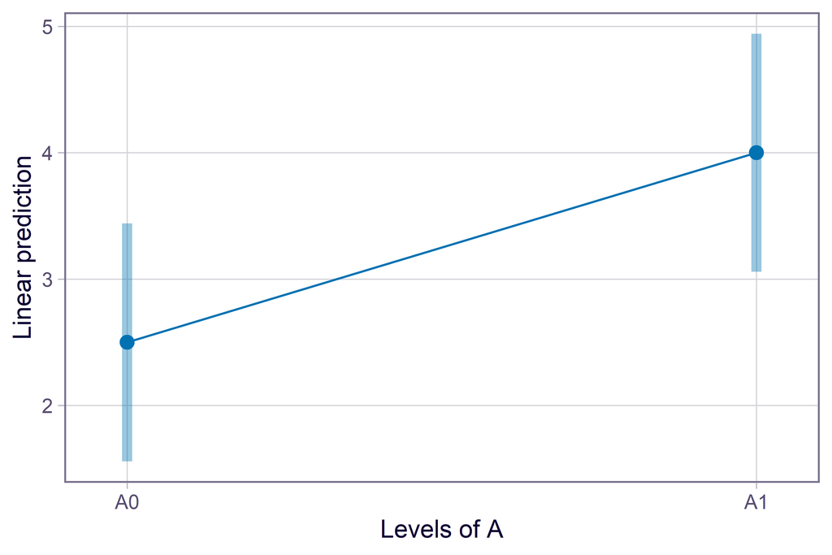

```r
emmip(m, ~ B, CIs=TRUE)
```

```
NOTE: Results may be misleading due to involvement in interactions
```

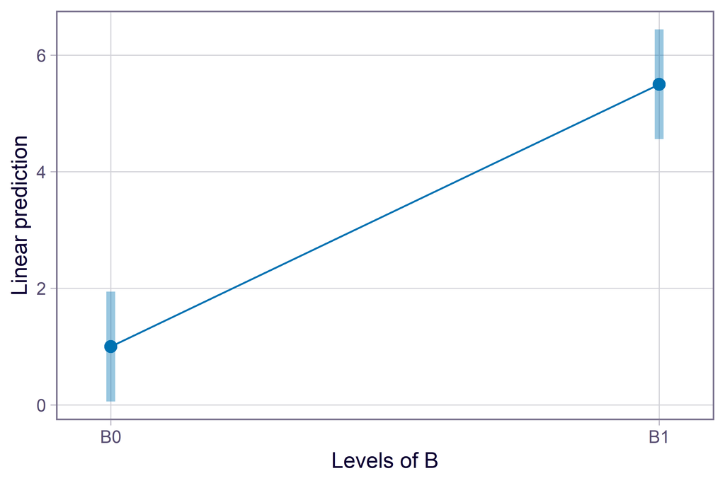

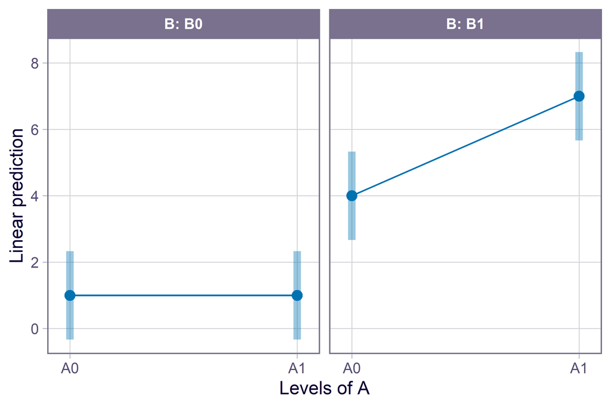

```r
emmip(m, ~ A | B, CIs=TRUE)
```

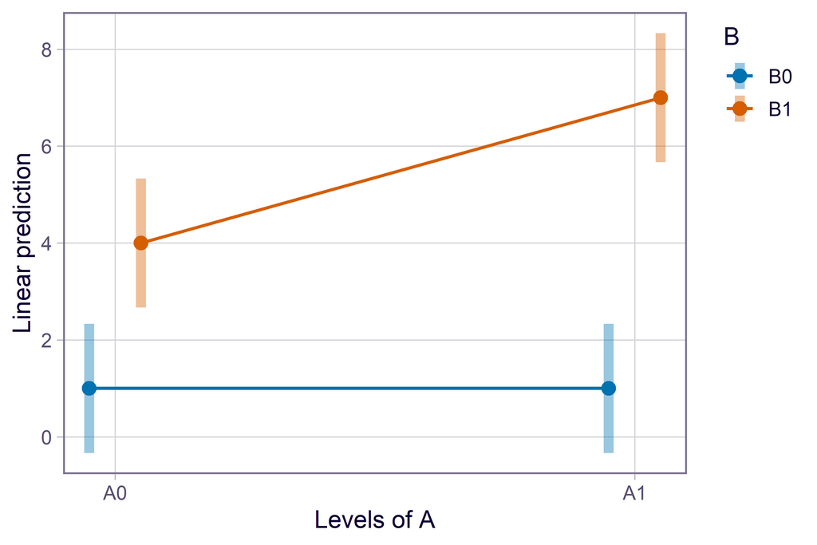

```r
emmip(m, B ~ A, CIs=TRUE)
```

#### 【实践1】截距模型

```r
## lm(formula=..., data=...)

m1 = lm(Y ~ 1, data)  # 1表示模型截距
summary(m1)
```

```
Call:
lm(formula = Y ~ 1, data = data)

Residuals:
   Min     1Q Median     3Q    Max
 -3.25  -2.25  -0.75   2.00   4.75

Coefficients:
            Estimate Std. Error t value Pr(>|t|)
(Intercept)    3.250      0.789    4.12   0.0017 **
---
Signif. codes:  0 '***' 0.001 '**' 0.01 '*' 0.05 '.' 0.1 ' ' 1

Residual standard error: 2.73 on 11 degrees of freedom
```

```r
bruceR::model_summary(m1)
```

```
Model Summary

──────────────────────
             (1) Y
──────────────────────
(Intercept)   3.250 **
             (0.789)
──────────────────────
R^2           0.000
Adj. R^2      0.000
Num. obs.    12
──────────────────────
Note. * p < .05, ** p < .01, *** p < .001.
```

```
Not enough model terms in the conditional part of the model to check for
  multicollinearity.
```

```r
sjPlot::tab_model(m1)
```

|  | Y |  |  |
| --- | --- | --- | --- |
| Predictors | Estimates | CI | p |
| (Intercept) | 3.25 | 1.51 – 4.99 | **0.002** |
| Observations | 12 |  |  |
| R<sup>2</sup> / R<sup>2</sup> adjusted | 0.000 / 0.000 |  |  |

```r
sjPlot::tab_model(
  m1, digits=3, show.ci=FALSE,
  show.se=TRUE, collapse.se=TRUE
)
```

|  | Y |  |
| --- | --- | --- |
| Predictors | Estimates | p |
| (Intercept) | 3.250 (0.789) | **0.002** |
| Observations | 12 |  |
| R<sup>2</sup> / R<sup>2</sup> adjusted | 0.000 / 0.000 |  |

```r
## 截距含义：Y的均值
mean(data$Y)  # 截距等于均值
```

```
[1] 3.25
```

```r
predict(m1)  # 预测期望值
```

```
   1    2    3    4    5    6    7    8    9   10   11   12
3.25 3.25 3.25 3.25 3.25 3.25 3.25 3.25 3.25 3.25 3.25 3.25
```

```r
TTEST(data, y="Y", digits=3)  # 截距模型等价于单样本t检验
```

```
One-Sample t-test

Hypothesis: two-sided (μ ≠ 0)

Descriptives:
──────────────────────────
 Variable  N   Mean (S.D.)
──────────────────────────
        Y 12 3.250 (2.734)
──────────────────────────

Results of t-test:
────────────────────────────────────────────────────────────────────────
                t df     p      Difference [95% CI]   Cohen’s d [95% CI]
────────────────────────────────────────────────────────────────────────
Y: (Y - 0)  4.117 11  .002 **  3.250 [1.513, 4.987] 1.189 [0.553, 1.824]
────────────────────────────────────────────────────────────────────────
```

#### 【实践2】一元回归模型

```r
m2 = lm(Y ~ 1 + A, data)
m2 = lm(Y ~ A, data)  # 相当于：Y ~ 1 + A
# 当有自变量时，截距1默认存在，可省略不写
summary(m2)
```

```
Call:
lm(formula = Y ~ A, data = data)

Residuals:
   Min     1Q Median     3Q    Max
 -4.00  -2.12   0.00   2.12   4.00

Coefficients:
            Estimate Std. Error t value Pr(>|t|)
(Intercept)     2.50       1.12    2.23     0.05 *
A               1.50       1.59    0.95     0.37
---
Signif. codes:  0 '***' 0.001 '**' 0.01 '*' 0.05 '.' 0.1 ' ' 1

Residual standard error: 2.75 on 10 degrees of freedom
Multiple R-squared:  0.0821,    Adjusted R-squared:  -0.00973
F-statistic: 0.894 on 1 and 10 DF,  p-value: 0.367
```

```r
tab_model(m2, digits=3, show.ci=FALSE,
          show.se=TRUE, collapse.se=TRUE)
```

|  | Y |  |
| --- | --- | --- |
| Predictors | Estimates | p |
| (Intercept) | 2.500 (1.122) | **0.050** |
| A | 1.500 (1.586) | 0.367 |
| Observations | 12 |  |
| R<sup>2</sup> / R<sup>2</sup> adjusted | 0.082 / -0.010 |  |

```r
## 截距含义：A=0时，Y的预测期望值（等于均值）
mean(data[A==0]$Y)
```

```
[1] 2.5
```

```r
predict(m2)  # 预测期望值
```

```
  1   2   3   4   5   6   7   8   9  10  11  12
2.5 2.5 2.5 2.5 2.5 2.5 4.0 4.0 4.0 4.0 4.0 4.0
```

```r
predict(m2, data.table(A=0))  # A=0时，Y的预测期望值
```

```
  1
2.5
```

```r
## 斜率含义：A从0变到1，Y的均值变化
TTEST(data, y="Y", x="A", digits=3)  # 一元回归等价于独立样本t检验
```

```
Independent-Samples t-test

Hypothesis: two-sided (μ2 - μ1 ≠ 0)

Descriptives:
──────────────────────────────────────
 Variable Factor Level N   Mean (S.D.)
──────────────────────────────────────
        Y      A     0 6 2.500 (1.871)
        Y      A     1 6 4.000 (3.406)
──────────────────────────────────────

Levene’s test for homogeneity of variance:
──────────────────────────────────────────
              Levene’s F df1 df2     p
──────────────────────────────────────────
Y: A (1 - 0)        8.44   1  10  .016 *
──────────────────────────────────────────
Note: H0 = equal variance (homoscedasticity).
If significant (violation of the assumption),
then you should better set `var.equal=FALSE`.

Results of t-test:
────────────────────────────────────────────────────────────────────────────
                  t df     p       Difference [95% CI]    Cohen’s d [95% CI]
────────────────────────────────────────────────────────────────────────────
Y: A (1 - 0)  0.946 10  .367     1.500 [-2.035, 5.035] 0.546 [-0.741, 1.832]
────────────────────────────────────────────────────────────────────────────
```

```r
m3 = lm(Y ~ 1 + B, data)
m3 = lm(Y ~ B, data)  # 相当于：Y ~ 1 + B
# 当有自变量时，截距1默认存在，可省略不写
summary(m3)
```

```
Call:
lm(formula = Y ~ B, data = data)

Residuals:
   Min     1Q Median     3Q    Max
  -2.5   -1.0    0.0    1.0    2.5

Coefficients:
            Estimate Std. Error t value Pr(>|t|)
(Intercept)    1.000      0.599    1.67  0.12577
B              4.500      0.847    5.32  0.00034 ***
---
Signif. codes:  0 '***' 0.001 '**' 0.01 '*' 0.05 '.' 0.1 ' ' 1

Residual standard error: 1.47 on 10 degrees of freedom
Multiple R-squared:  0.739, Adjusted R-squared:  0.712
F-statistic: 28.3 on 1 and 10 DF,  p-value: 0.00034
```

```r
tab_model(m3, digits=3, show.ci=FALSE,
          show.se=TRUE, collapse.se=TRUE)
```

|  | Y |  |
| --- | --- | --- |
| Predictors | Estimates | p |
| (Intercept) | 1.000 (0.599) | 0.126 |
| B | 4.500 (0.847) | **<0.001** |
| Observations | 12 |  |
| R<sup>2</sup> / R<sup>2</sup> adjusted | 0.739 / 0.712 |  |

```r
## 截距含义：B=0时，Y的预测期望值（等于均值）
mean(data[B==0]$Y)
```

```
[1] 1
```

```r
predict(m3)  # 预测期望值
```

```
  1   2   3   4   5   6   7   8   9  10  11  12
1.0 1.0 1.0 5.5 5.5 5.5 1.0 1.0 1.0 5.5 5.5 5.5
```

```r
predict(m3, data.table(B=0))  # B=0时，Y的预测期望值
```

```
1
1
```

```r
## 斜率含义：B从0变到1，Y的均值变化
TTEST(data, y="Y", x="B", digits=3)  # 一元回归等价于独立样本t检验
```

```
Independent-Samples t-test

Hypothesis: two-sided (μ2 - μ1 ≠ 0)

Descriptives:
──────────────────────────────────────
 Variable Factor Level N   Mean (S.D.)
──────────────────────────────────────
        Y      B     0 6 1.000 (0.894)
        Y      B     1 6 5.500 (1.871)
──────────────────────────────────────

Levene’s test for homogeneity of variance:
──────────────────────────────────────────
              Levene’s F df1 df2     p
──────────────────────────────────────────
Y: B (1 - 0)        3.91   1  10  .076 .
──────────────────────────────────────────
Note: H0 = equal variance (homoscedasticity).
If significant (violation of the assumption),
then you should better set `var.equal=FALSE`.

Results of t-test:
──────────────────────────────────────────────────────────────────────────
                  t df     p      Difference [95% CI]   Cohen’s d [95% CI]
──────────────────────────────────────────────────────────────────────────
Y: B (1 - 0)  5.316 10 <.001 *** 4.500 [2.614, 6.386] 3.069 [1.783, 4.355]
──────────────────────────────────────────────────────────────────────────
```

#### 【实践3】多元回归模型

```r
m4 = lm(Y ~ A + B, data)  # 相当于：Y ~ 1 + A + B
# 当有自变量时，截距1默认存在，可省略不写
summary(m4)
```

```
Call:
lm(formula = Y ~ A + B, data = data)

Residuals:
   Min     1Q Median     3Q    Max
 -1.75  -0.75   0.00   0.75   1.75

Coefficients:
            Estimate Std. Error t value Pr(>|t|)
(Intercept)    0.250      0.640    0.39  0.70520
A              1.500      0.739    2.03  0.07300 .
B              4.500      0.739    6.09  0.00018 ***
---
Signif. codes:  0 '***' 0.001 '**' 0.01 '*' 0.05 '.' 0.1 ' ' 1

Residual standard error: 1.28 on 9 degrees of freedom
Multiple R-squared:  0.821, Adjusted R-squared:  0.781
F-statistic: 20.6 on 2 and 9 DF,  p-value: 0.000438
```

```r
tab_model(m4, digits=3, show.ci=FALSE,
          show.se=TRUE, collapse.se=TRUE)
```

|  | Y |  |
| --- | --- | --- |
| Predictors | Estimates | p |
| (Intercept) | 0.250 (0.640) | 0.705 |
| A | 1.500 (0.739) | 0.073 |
| B | 4.500 (0.739) | **<0.001** |
| Observations | 12 |  |
| R<sup>2</sup> / R<sup>2</sup> adjusted | 0.821 / 0.781 |  |

```r
## 截距含义：A=B=0时，Y的预测期望值（此时不再是简单均值）
mean(data[A==0 & B==0]$Y)  # 简单均值
```

```
[1] 1
```

```r
predict(m4, data.table(A=0, B=0))  # A=B=0时，Y的预测期望值
```

```
   1
0.25
```

```r
## 斜率含义：A或B从0变到1，Y的预测期望值变化
mean(data[A==1]$Y) - mean(data[A==0]$Y)
```

```
[1] 1.5
```

```r
mean(data[B==1]$Y) - mean(data[B==0]$Y)
```

```
[1] 4.5
```

#### 【实践4】交互作用模型

- R语言回归模型公式中的交互作用设定（适用于所有类型的回归模型）
  - `Y ~ A * B`（精简写法）
  - `Y ~ 1 + A + B + A:B`（展开写法）
    - `1`为截距（可省略不写）
    - `A`和`B`为一阶效应（“简单效应”、“条件效应”），并非ANOVA中的“主效应”！！！⭐️
    - `A:B`为交互项（interaction term）

```r
## 方差分析（回顾）
MANOVA(data, dv="Y", between=c("A", "B"))
```

```
====== ANOVA (Between-Subjects Design) ======

Descriptives:
────────────────────────
 "A" "B"  Mean    S.D. n
────────────────────────
  A0  B0 1.000 (1.000) 3
  A0  B1 4.000 (1.000) 3
  A1  B0 1.000 (1.000) 3
  A1  B1 7.000 (1.000) 3
────────────────────────
Total sample size: N = 12

ANOVA Table:
Dependent variable(s):      Y
Between-subjects factor(s): A, B
Within-subjects factor(s):  –
Covariate(s):               –
─────────────────────────────────────────────────────────────────────
           MS   MSE df1 df2      F     p     η²p [90% CI of η²p]  η²G
─────────────────────────────────────────────────────────────────────
A       6.750 1.000   1   8  6.750  .032 *     .458 [.034, .715] .458
B      60.750 1.000   1   8 60.750 <.001 ***   .884 [.680, .940] .884
A * B   6.750 1.000   1   8  6.750  .032 *     .458 [.034, .715] .458
─────────────────────────────────────────────────────────────────────
MSE = mean square error (the residual variance of the linear model)
η²p = partial eta-squared = SS / (SS + SSE) = F * df1 / (F * df1 + df2)
ω²p = partial omega-squared = (F - 1) * df1 / (F * df1 + df2 + 1)
η²G = generalized eta-squared (see Olejnik & Algina, 2003)
Cohen’s f² = η²p / (1 - η²p)

Levene’s Test for Homogeneity of Variance:
───────────────────────────────────
       Levene’s F df1 df2     p
───────────────────────────────────
DV: Y       0.000   3   8 1.000
───────────────────────────────────
```

```r
## 回归分析
m5 = lm(Y ~ A * B, data)  # 相当于：Y ~ 1 + A + B + A:B
anova(m5)  # 回归模型各因素的F检验（Type I SS）：主效应、交互作用
```

```
Analysis of Variance Table

Response: Y
          Df Sum Sq Mean Sq F value  Pr(>F)
A          1    6.7     6.7    6.75   0.032 *
B          1   60.7    60.7   60.75 5.3e-05 ***
A:B        1    6.8     6.8    6.75   0.032 *
Residuals  8    8.0     1.0
---
Signif. codes:  0 '***' 0.001 '**' 0.01 '*' 0.05 '.' 0.1 ' ' 1
```

- The standard R `anova()` function calculates sequential (“Type I”) tests. These rarely test interesting hypotheses in *unbalanced* designs.
- R语言内置`anova()`：“I型平方和”的*F*检验
  - 只适用于平衡样本情况，如果组间样本不平衡，则与“III型平方和”不一致
- 推荐使用`emmeans::joint_tests()`：“III型平方和”的*F*检验或卡方检验
  - 更通用的**主效应检验**函数！！！⭐️

```r
emmeans::joint_tests(m5)  # 联合对比检验（Type III SS）：真正的主效应、交互作用
```

```
 model term df1 df2 F.ratio p.value
 A            1   8   6.750  0.0317
 B            1   8  60.750 <0.0001
 A:B          1   8   6.750  0.0317
```

```r
summary(m5)  # A和B的简单效应（条件效应），并非“主效应”！！！
```

```
Call:
lm(formula = Y ~ A * B, data = data)

Residuals:
   Min     1Q Median     3Q    Max
    -1     -1      0      1      1

Coefficients:
             Estimate Std. Error t value Pr(>|t|)
(Intercept)  1.00e+00   5.77e-01    1.73   0.1215
A           -1.09e-15   8.16e-01    0.00   1.0000
B            3.00e+00   8.16e-01    3.67   0.0063 **
A:B          3.00e+00   1.15e+00    2.60   0.0317 *
---
Signif. codes:  0 '***' 0.001 '**' 0.01 '*' 0.05 '.' 0.1 ' ' 1

Residual standard error: 1 on 8 degrees of freedom
Multiple R-squared:  0.903, Adjusted R-squared:  0.866
F-statistic: 24.8 on 3 and 8 DF,  p-value: 0.000212
```

```r
## A和B的简单效应（条件效应），并非“主效应”！！！
tab_model(m5, digits=3, show.ci=FALSE,
          show.se=TRUE, collapse.se=TRUE)
```

|  | Y |  |
| --- | --- | --- |
| Predictors | Estimates | p |
| (Intercept) | 1.000 (0.577) | 0.122 |
| A | -0.000 (0.816) | 1.000 |
| B | 3.000 (0.816) | **0.006** |
| A × B | 3.000 (1.155) | **0.032** |
| Observations | 12 |  |
| R<sup>2</sup> / R<sup>2</sup> adjusted | 0.903 / 0.866 |  |

#### 【知识点】为什么回归分析交互作用中的斜率并不是“主效应”？

- 回归分析中，如果存在交互作用（A × B），则每个自变量的斜率代表另一个变量取0时，该变量的**简单斜率（一阶效应、简单效应、条件效应）**！
- 在【实践4】模型结果中：
  - A的斜率/条件效应（*b* = 0.00）：B = 0时，A的简单斜率（1.00 – 1.00 = 0.00）
  - B的斜率/条件效应（*b* = 3.00）：A = 0时，B的简单斜率（4.00 – 1.00 = 3.00）
- 而真正的主效应结果是：
  - A的主效应/边际效应：无论B，A1与A0的边际均值差异（4.00 – 2.50 = 1.50）
  - B的主效应/边际效应：无论A，B1与B0的边际均值差异（5.50 – 1.00 = 4.50）

表1. 原始数据

| 原始数据 | B0条件 | B1条件 |
| --- | --- | --- |
| **A0条件** | 0, 1, 2 | 3, 4, 5 |
| **A1条件** | 0, 1, 2 | 6, 7, 8 |

表2. A和B的条件均值与边际均值

| 均值 | B0条件均值 | B1条件均值 | 边际均值 |
| --- | --- | --- | --- |
| **A0条件均值** | **1.00** | **4.00** | 2.50 |
| **A1条件均值** | **1.00** | **7.00** | 4.00 |
| **边际均值** | 1.00 | 5.50 | 3.25 |

```r
## 注意，这不是A和B的主效应！（这是简单效应、条件效应！）
tab_model(m5, digits=3, show.ci=FALSE,
          show.se=TRUE, collapse.se=TRUE)
```

|  | Y |  |
| --- | --- | --- |
| Predictors | Estimates | p |
| (Intercept) | 1.000 (0.577) | 0.122 |
| A | -0.000 (0.816) | 1.000 |
| B | 3.000 (0.816) | **0.006** |
| A × B | 3.000 (1.155) | **0.032** |
| Observations | 12 |  |
| R<sup>2</sup> / R<sup>2</sup> adjusted | 0.903 / 0.866 |  |

```r
## 对比方差分析“简单效应”结果
EMMEANS(m, "A", by="B")
```

```
------ EMMEANS (effect = "A") ------

Joint Tests of "A":
────────────────────────────────────────────────────────
 Effect "B" df1 df2      F     p     η²p [90% CI of η²p]
────────────────────────────────────────────────────────
      A  B0   1   8  0.000 1.000       .000 [.000, .000]
      A  B1   1   8 13.500  .006 **    .628 [.191, .808]
────────────────────────────────────────────────────────
Note. Simple effects of repeated measures with 3 or more levels
are different from the results obtained with SPSS MANOVA syntax.

Univariate Tests of "A":
─────────────────────────────────────────────────────────
           Sum of Squares df Mean Square      F     p
─────────────────────────────────────────────────────────
B0: "A"             0.000  1       0.000  0.000 1.000
B1: "A"            13.500  1      13.500 13.500  .006 **
Residuals           8.000  8       1.000
─────────────────────────────────────────────────────────
Note. Identical to the results obtained with SPSS GLM EMMEANS syntax.

Estimated Marginal Means of "A":
──────────────────────────────────────
 "A" "B" Mean [95% CI of Mean]    S.E.
──────────────────────────────────────
  A0  B0 1.000 [-0.331, 2.331] (0.577)
  A1  B0 1.000 [-0.331, 2.331] (0.577)
  A0  B1 4.000 [ 2.669, 5.331] (0.577)
  A1  B1 7.000 [ 5.669, 8.331] (0.577)
──────────────────────────────────────

Pairwise Comparisons of "A":
─────────────────────────────────────────────────────────────────────────
 Contrast "B" Estimate    S.E. df     t     p     Cohen’s d [95% CI of d]
─────────────────────────────────────────────────────────────────────────
  A1 - A0  B0    0.000 (0.816)  8 0.000 1.000       0.000 [-1.883, 1.883]
  A1 - A0  B1    3.000 (0.816)  8 3.674  .006 **    3.000 [ 1.117, 4.883]
─────────────────────────────────────────────────────────────────────────
Pooled SD for computing Cohen’s d: 1.000
No need to adjust p values.

Disclaimer:
By default, pooled SD is Root Mean Square Error (RMSE).
There is much disagreement on how to compute Cohen’s d.
You are completely responsible for setting `sd.pooled`.
You might also use `effectsize::t_to_d()` to compute d.
```

#### 【实践5】如何让回归分析交互作用中的斜率具有“主效应”含义？

- 变量中心化（[Chap05](https://psychbruce.github.io/RCourse/Chap05#%E5%8F%98%E9%87%8F%E4%B8%AD%E5%BF%83%E5%8C%96%E4%B8%8E%E6%A0%87%E5%87%86%E5%8C%96)）：使新变量（B’）取0等价于原变量（B）取均值
  - 中心化消除了“边际效应”与“条件效应”之间的偏差
    - 边际效应（主效应）= 条件效应（一阶斜率）+ 交互效应 × 调节变量均值
    - $\text{Main Effect}_X = b_{X_{Marginal}} = b_{X_{Conditional}} + b_{X*M_{Interaction}} \bar{M}$
    - $\text{Main Effect}_A = 1.50 = 0.00 + 3.00 \times (0+1)/2$
    - $\text{Main Effect}_B = 4.50 = 3.00 + 3.00 \times (0+1)/2$

```r
## 中心化处理
data$A.c = data$A - mean(data$A)  # 也可以直接用 grand_mean_center()
data$B.c = data$B - mean(data$B)  # 也可以直接用 grand_mean_center()
data
```

```
索引(index): <A>, <B>, <B__A>
        A     B     Y   A.c   B.c
    <num> <num> <num> <num> <num>
 1:     0     0     0  -0.5  -0.5
 2:     0     0     1  -0.5  -0.5
 3:     0     0     2  -0.5  -0.5
 4:     0     1     3  -0.5   0.5
 5:     0     1     4  -0.5   0.5
 6:     0     1     5  -0.5   0.5
 7:     1     0     0   0.5  -0.5
 8:     1     0     1   0.5  -0.5
 9:     1     0     2   0.5  -0.5
10:     1     1     6   0.5   0.5
11:     1     1     7   0.5   0.5
12:     1     1     8   0.5   0.5
```

```r
m6 = lm(Y ~ A.c * B.c, data)
anova(m6)  # 回归模型各因素的F检验（Type I SS）：主效应、交互作用
```

```
Analysis of Variance Table

Response: Y
          Df Sum Sq Mean Sq F value  Pr(>F)
A.c        1    6.8     6.8    6.75   0.032 *
B.c        1   60.7    60.7   60.75 5.3e-05 ***
A.c:B.c    1    6.8     6.8    6.75   0.032 *
Residuals  8    8.0     1.0
---
Signif. codes:  0 '***' 0.001 '**' 0.01 '*' 0.05 '.' 0.1 ' ' 1
```

```r
emmeans::joint_tests(m6)  # 联合对比检验（Type III SS）：真正的主效应、交互作用
```

```
 model term df1 df2 F.ratio p.value
 A.c          1   8   6.750  0.0317
 B.c          1   8  60.750 <0.0001
 A.c:B.c      1   8   6.750  0.0317
```

```r
summary(m6)  # A和B中心化后，简单效应（条件效应）等价于“主效应”
```

```
Call:
lm(formula = Y ~ A.c * B.c, data = data)

Residuals:
   Min     1Q Median     3Q    Max
    -1     -1      0      1      1

Coefficients:
            Estimate Std. Error t value Pr(>|t|)
(Intercept)    3.250      0.289   11.26  3.5e-06 ***
A.c            1.500      0.577    2.60    0.032 *
B.c            4.500      0.577    7.79  5.3e-05 ***
A.c:B.c        3.000      1.155    2.60    0.032 *
---
Signif. codes:  0 '***' 0.001 '**' 0.01 '*' 0.05 '.' 0.1 ' ' 1

Residual standard error: 1 on 8 degrees of freedom
Multiple R-squared:  0.903, Adjusted R-squared:  0.866
F-statistic: 24.8 on 3 and 8 DF,  p-value: 0.000212
```

```r
## A和B中心化后，简单效应（条件效应）等价于“主效应”
tab_model(m6, digits=3, show.ci=FALSE,
          show.se=TRUE, collapse.se=TRUE)
```

|  | Y |  |
| --- | --- | --- |
| Predictors | Estimates | p |
| (Intercept) | 3.250 (0.289) | **<0.001** |
| A c | 1.500 (0.577) | **0.032** |
| B c | 4.500 (0.577) | **<0.001** |
| A c × B c | 3.000 (1.155) | **0.032** |
| Observations | 12 |  |
| R<sup>2</sup> / R<sup>2</sup> adjusted | 0.903 / 0.866 |  |

```r
## 2×3两因素被试间设计的回归分析
d = between.2
d$A = as.factor(d$A)
d$B = as.factor(d$B)

MANOVA(d, dv="SCORE", between=c("A", "B"))
```

```
====== ANOVA (Between-Subjects Design) ======

Descriptives:
─────────────────────────
 "A" "B"   Mean    S.D. n
─────────────────────────
  A1  B1  4.000 (1.414) 4
  A1  B2  4.000 (1.633) 4
  A1  B3  4.750 (2.062) 4
  A2  B1  3.750 (0.957) 4
  A2  B2  8.000 (0.816) 4
  A2  B3 12.000 (0.816) 4
─────────────────────────
Total sample size: N = 24

ANOVA Table:
Dependent variable(s):      SCORE
Between-subjects factor(s): A, B
Within-subjects factor(s):  –
Covariate(s):               –
─────────────────────────────────────────────────────────────────────
           MS   MSE df1 df2      F     p     η²p [90% CI of η²p]  η²G
─────────────────────────────────────────────────────────────────────
A      80.667 1.861   1  18 43.343 <.001 ***   .707 [.482, .817] .707
B      40.542 1.861   2  18 21.784 <.001 ***   .708 [.470, .815] .708
A * B  28.292 1.861   2  18 15.201 <.001 ***   .628 [.347, .763] .628
─────────────────────────────────────────────────────────────────────
MSE = mean square error (the residual variance of the linear model)
η²p = partial eta-squared = SS / (SS + SSE) = F * df1 / (F * df1 + df2)
ω²p = partial omega-squared = (F - 1) * df1 / (F * df1 + df2 + 1)
η²G = generalized eta-squared (see Olejnik & Algina, 2003)
Cohen’s f² = η²p / (1 - η²p)

Levene’s Test for Homogeneity of Variance:
───────────────────────────────────────
           Levene’s F df1 df2     p
───────────────────────────────────────
DV: SCORE       0.605   5  18  .697
───────────────────────────────────────
```

```r
model = lm(SCORE ~ A * B, data=d)
summary(model)  # A和B的简单效应（条件效应），并非“主效应”！！！
```

```
Call:
lm(formula = SCORE ~ A * B, data = d)

Residuals:
   Min     1Q Median     3Q    Max
-2.750 -0.812  0.000  0.438  2.250

Coefficients:
             Estimate Std. Error t value Pr(>|t|)
(Intercept)  4.00e+00   6.82e-01    5.86  1.5e-05 ***
A2          -2.50e-01   9.65e-01   -0.26    0.798
B2           1.68e-15   9.65e-01    0.00    1.000
B3           7.50e-01   9.65e-01    0.78    0.447
A2:B2        4.25e+00   1.36e+00    3.12    0.006 **
A2:B3        7.50e+00   1.36e+00    5.50  3.2e-05 ***
---
Signif. codes:  0 '***' 0.001 '**' 0.01 '*' 0.05 '.' 0.1 ' ' 1

Residual standard error: 1.36 on 18 degrees of freedom
Multiple R-squared:  0.867, Adjusted R-squared:  0.83
F-statistic: 23.5 on 5 and 18 DF,  p-value: 2.66e-07
```

```r
anova(model)  # 回归模型各因素的F检验（Type I SS）：主效应、交互作用
```

```
Analysis of Variance Table

Response: SCORE
          Df Sum Sq Mean Sq F value  Pr(>F)
A          1   80.7    80.7    43.3 3.5e-06 ***
B          2   81.1    40.5    21.8 1.6e-05 ***
A:B        2   56.6    28.3    15.2 0.00014 ***
Residuals 18   33.5     1.9
---
Signif. codes:  0 '***' 0.001 '**' 0.01 '*' 0.05 '.' 0.1 ' ' 1
```

```r
emmeans::joint_tests(model)  # 联合对比检验（Type III SS）：真正的主效应、交互作用
```

```
 model term df1 df2 F.ratio p.value
 A            1  18  43.340 <0.0001
 B            2  18  21.780 <0.0001
 A:B          2  18  15.200  0.0001
```

# 多个模型汇总与表格输出

#### 【实践6】多元回归模型的结果表输出

模型结果表可以输出到：

- R Console控制台
- Microsoft Word文档
- HTML表格

```r
m1 = lm(Y ~ 1, data)
m2 = lm(Y ~ A, data)
m3 = lm(Y ~ B, data)
m4 = lm(Y ~ A + B, data)
m5 = lm(Y ~ A * B, data)
m6 = lm(Y ~ A.c * B.c, data)

model_summary(list(m1, m2, m3, m4, m5, m6))
```

```
Model Summary

───────────────────────────────────────────────────────────────────────────────
             (1) Y      (2) Y     (3) Y       (4) Y       (5) Y      (6) Y
───────────────────────────────────────────────────────────────────────────────
(Intercept)   3.250 **   2.500 *   1.000       0.250       1.000      3.250 ***
             (0.789)    (1.122)   (0.599)     (0.640)     (0.577)    (0.289)
A                        1.500                 1.500      -0.000
                        (1.586)               (0.739)     (0.816)
B                                  4.500 ***   4.500 ***   3.000 **
                                  (0.847)     (0.739)     (0.816)
A:B                                                        3.000 *
                                                          (1.155)
A.c                                                                   1.500 *
                                                                     (0.577)
B.c                                                                   4.500 ***
                                                                     (0.577)
A.c:B.c                                                               3.000 *
                                                                     (1.155)
───────────────────────────────────────────────────────────────────────────────
R^2           0.000      0.082     0.739       0.821       0.903      0.903
Adj. R^2      0.000     -0.010     0.712       0.781       0.866      0.866
Num. obs.    12         12        12          12          12         12
───────────────────────────────────────────────────────────────────────────────
Note. * p < .05, ** p < .01, *** p < .001.
```

```r
model_summary(list(m1, m2, m3, m4, m5, m6),
              digits=2,
              file="Models.doc")
```

```
✔ Table saved to 'D:/RStudio/RCourse/Models.doc'
```

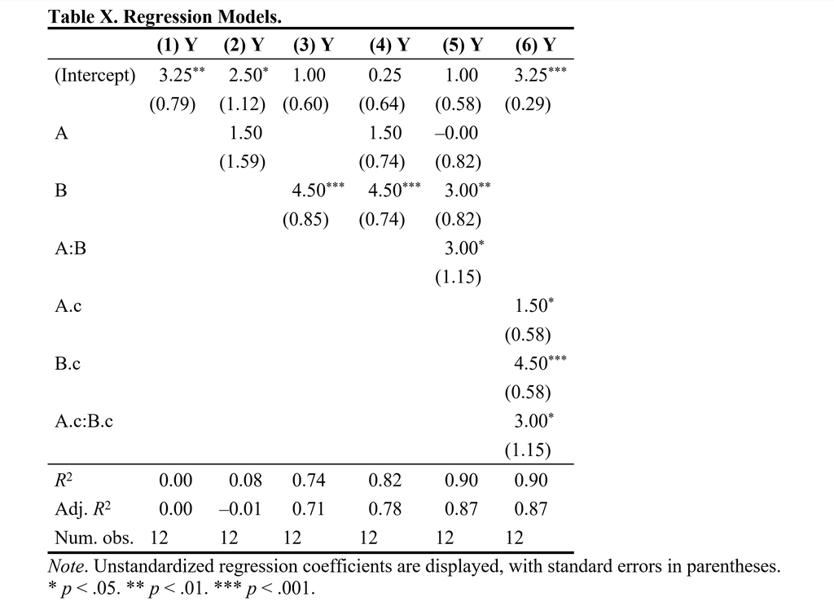

```r
tab_model(m1, m2, m3, m4, m5, m6,
          digits=2, string.est="b (SE)",
          show.ci=FALSE, show.se=TRUE, collapse.se=TRUE)
```

|  | Y |  | Y |  | Y |  | Y |  | Y |  | Y |  |
| --- | --- | --- | --- | --- | --- | --- | --- | --- | --- | --- | --- | --- |
| Predictors | b (SE) | p | b (SE) | p | b (SE) | p | b (SE) | p | b (SE) | p | b (SE) | p |
| (Intercept) | 3.25 (0.79) | **0.002** | 2.50 (1.12) | **0.050** | 1.00 (0.60) | 0.126 | 0.25 (0.64) | 0.705 | 1.00 (0.58) | 0.122 | 3.25 (0.29) | **<0.001** |
| A |  |  | 1.50 (1.59) | 0.367 |  |  | 1.50 (0.74) | 0.073 | -0.00 (0.82) | 1.000 |  |  |
| B |  |  |  |  | 4.50 (0.85) | **<0.001** | 4.50 (0.74) | **<0.001** | 3.00 (0.82) | **0.006** |  |  |
| A × B |  |  |  |  |  |  |  |  | 3.00 (1.15) | **0.032** |  |  |
| A c |  |  |  |  |  |  |  |  |  |  | 1.50 (0.58) | **0.032** |
| B c |  |  |  |  |  |  |  |  |  |  | 4.50 (0.58) | **<0.001** |
| A c × B c |  |  |  |  |  |  |  |  |  |  | 3.00 (1.15) | **0.032** |
| Observations | 12 |  | 12 |  | 12 |  | 12 |  | 12 |  | 12 |  |
| R<sup>2</sup> / R<sup>2</sup> adjusted | 0.000 / 0.000 |  | 0.082 / -0.010 |  | 0.739 / 0.712 |  | 0.821 / 0.781 |  | 0.903 / 0.866 |  | 0.903 / 0.866 |  |

#### 【实践7】空气质量数据回归分析实例

```r
## 数据准备
str(airquality)
```

```
'data.frame':   153 obs. of  6 variables:
 $ Ozone  : int  41 36 12 18 NA 28 23 19 8 NA ...
 $ Solar.R: int  190 118 149 313 NA NA 299 99 19 194 ...
 $ Wind   : num  7.4 8 12.6 11.5 14.3 14.9 8.6 13.8 20.1 8.6 ...
 $ Temp   : int  67 72 74 62 56 66 65 59 61 69 ...
 $ Month  : int  5 5 5 5 5 5 5 5 5 5 ...
 $ Day    : int  1 2 3 4 5 6 7 8 9 10 ...
```

```r
Corr(airquality)
```

```
Pearson's r and 95% confidence intervals:
─────────────────────────────────────────────────
                   r       [95% CI]     p       N
─────────────────────────────────────────────────
Ozone-Solar.R   0.35 [ 0.17,  0.50] <.001 *** 111
Ozone-Wind     -0.60 [-0.71, -0.47] <.001 *** 116
Ozone-Temp      0.70 [ 0.59,  0.78] <.001 *** 116
Ozone-Month     0.16 [-0.02,  0.34]  .078 .   116
Ozone-Day      -0.01 [-0.20,  0.17]  .888     116
Solar.R-Wind   -0.06 [-0.22,  0.11]  .496     146
Solar.R-Temp    0.28 [ 0.12,  0.42] <.001 *** 146
Solar.R-Month  -0.08 [-0.23,  0.09]  .366     146
Solar.R-Day    -0.15 [-0.31,  0.01]  .070 .   146
Wind-Temp      -0.46 [-0.57, -0.32] <.001 *** 153
Wind-Month     -0.18 [-0.33, -0.02]  .027 *   153
Wind-Day        0.03 [-0.13,  0.19]  .739     153
Temp-Month      0.42 [ 0.28,  0.54] <.001 *** 153
Temp-Day       -0.13 [-0.28,  0.03]  .108     153
Month-Day      -0.01 [-0.17,  0.15]  .922     153
─────────────────────────────────────────────────
```

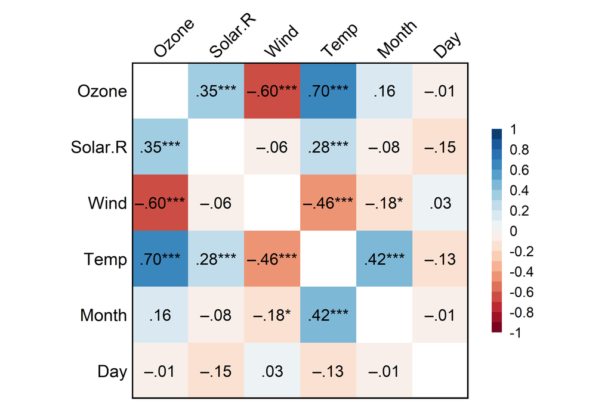

```r
## 回归分析
m1 = lm(Ozone ~ Solar.R, data=airquality)
m2 = lm(Ozone ~ Solar.R + Temp, data=airquality)
m3 = lm(Ozone ~ Solar.R + Temp + Wind, data=airquality)
m4 = lm(Ozone ~ Solar.R + Temp + Wind + Month, data=airquality)
model = lm(Ozone ~ ., data=airquality)  # . 表示纳入剩余所有变量
```

思考：

- 截距（*b* = –64.116, *p* = .007）的含义是？
- 气温斜率（*b* = 1.896, β = .543, *p* < .001）的含义是？
- *t*值与*b*、*SE*的关系是？（请验算一下）

$$t = \frac{b}{SE}$$

```r
## bruceR系列函数
GLM_summary(model)
```

```
General Linear Model (OLS Regression)

Model Fit:
F(5, 105) = 34.99, p = 7e-21 ***
R² = 0.62494 (Adjusted R² = 0.60708)

Unstandardized Coefficients:
Outcome Variable: Ozone
N = 111 (42 missing cases deleted)
────────────────────────────────────────────────────────────────────────
                   b     S.E.      t     p           [95% CI of b]   VIF
────────────────────────────────────────────────────────────────────────
(Intercept)  -64.116 (23.482) -2.730  .007 **  [-110.678, -17.555]
Solar.R        0.050 ( 0.023)  2.147  .034 *   [   0.004,   0.097] 1.152
Wind          -3.318 ( 0.645) -5.149 <.001 *** [  -4.596,  -2.041] 1.329
Temp           1.896 ( 0.274)  6.922 <.001 *** [   1.353,   2.439] 1.722
Month         -3.040 ( 1.513) -2.009  .047 *   [  -6.041,  -0.039] 1.257
Day            0.274 ( 0.230)  1.192  .236     [  -0.182,   0.729] 1.011
────────────────────────────────────────────────────────────────────────

Standardized Coefficients (β):
Outcome Variable: Ozone
N = 111 (42 missing cases deleted)
────────────────────────────────────────────────────────────────────────────
              β    S.E.      t     p        [95% CI of β] r(partial) r(part)
────────────────────────────────────────────────────────────────────────────
Solar.R   0.138 (0.064)  2.147  .034 *   [ 0.011,  0.265]      0.205   0.128
Wind     -0.355 (0.069) -5.149 <.001 *** [-0.491, -0.218]     -0.449  -0.308
Temp      0.543 (0.078)  6.922 <.001 *** [ 0.387,  0.698]      0.560   0.414
Month    -0.135 (0.067) -2.009  .047 *   [-0.267, -0.002]     -0.192  -0.120
Day       0.072 (0.060)  1.192  .236     [-0.047,  0.191]      0.116   0.071
────────────────────────────────────────────────────────────────────────────
```

```r
model_summary(model)
```

```
Model Summary

────────────────────────
             (1) Ozone
────────────────────────
(Intercept)  -64.116 **
             (23.482)
Solar.R        0.050 *
              (0.023)
Wind          -3.318 ***
              (0.645)
Temp           1.896 ***
              (0.274)
Month         -3.040 *
              (1.513)
Day            0.274
              (0.230)
────────────────────────
R^2            0.625
Adj. R^2       0.607
Num. obs.    111
────────────────────────
Note. * p < .05, ** p < .01, *** p < .001.

# Check for Multicollinearity

Low Correlation

    Term  VIF       VIF 95% CI adj. VIF Tolerance Tolerance 95% CI
 Solar.R 1.15 [1.03,     1.66]     1.07      0.87     [0.60, 0.97]
    Wind 1.33 [1.14,     1.78]     1.15      0.75     [0.56, 0.88]
    Temp 1.72 [1.40,     2.29]     1.31      0.58     [0.44, 0.71]
   Month 1.26 [1.09,     1.71]     1.12      0.80     [0.59, 0.91]
     Day 1.01 [1.00, 83489.99]     1.01      0.99     [0.00, 1.00]
```

```r
model_summary(model, std=TRUE)  # 标准化回归系数
```

```
Model Summary

──────────────────────
           (1) Ozone
──────────────────────
Solar.R       .138 *
             (.064)
Wind         -.355 ***
             (.069)
Temp          .543 ***
             (.078)
Month        -.135 *
             (.067)
Day           .072
             (.060)
──────────────────────
R^2           .625
Adj. R^2      .607
Num. obs.  111
──────────────────────
Note. * p < .05, ** p < .01, *** p < .001.

# Check for Multicollinearity

Low Correlation

    Term  VIF       VIF 95% CI adj. VIF Tolerance Tolerance 95% CI
 Solar.R 1.15 [1.03,     1.66]     1.07      0.87     [0.60, 0.97]
    Wind 1.33 [1.14,     1.78]     1.15      0.75     [0.56, 0.88]
    Temp 1.72 [1.40,     2.29]     1.31      0.58     [0.44, 0.71]
   Month 1.26 [1.09,     1.71]     1.12      0.80     [0.59, 0.91]
     Day 1.01 [1.00, 83489.99]     1.01      0.99     [0.00, 1.00]
```

```r
model_summary(list(m1, m2, m3, m4, model), file="Models.doc")
```

```
✔ Table saved to 'D:/RStudio/RCourse/Models.doc'
```

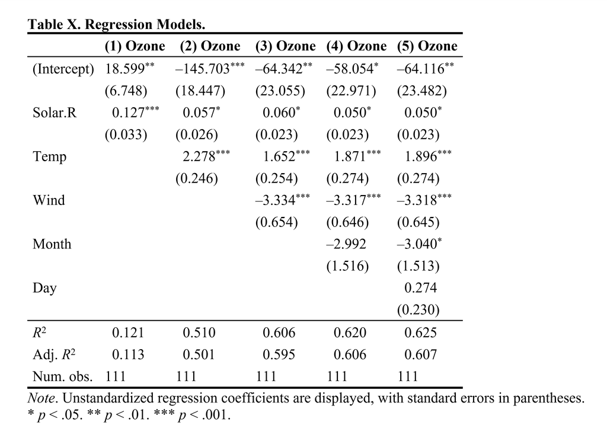

↑ APA格式表格，可直接复制到论文中

```r
## sjPlot系列函数
tab_model(model)
```

|  | Ozone |  |  |
| --- | --- | --- | --- |
| Predictors | Estimates | CI | p |
| (Intercept) | -64.12 | -110.68 – -17.55 | **0.007** |
| Solar R | 0.05 | 0.00 – 0.10 | **0.034** |
| Wind | -3.32 | -4.60 – -2.04 | **<0.001** |
| Temp | 1.90 | 1.35 – 2.44 | **<0.001** |
| Month | -3.04 | -6.04 – -0.04 | **0.047** |
| Day | 0.27 | -0.18 – 0.73 | 0.236 |
| Observations | 111 |  |  |
| R<sup>2</sup> / R<sup>2</sup> adjusted | 0.625 / 0.607 |  |  |

```r
tab_model(m1, m2, m3, m4, model,
          digits=3, string.est="b (SE)",
          show.ci=FALSE, show.se=TRUE, collapse.se=TRUE)
```

|  | Ozone |  | Ozone |  | Ozone |  | Ozone |  | Ozone |  |
| --- | --- | --- | --- | --- | --- | --- | --- | --- | --- | --- |
| Predictors | b (SE) | p | b (SE) | p | b (SE) | p | b (SE) | p | b (SE) | p |
| (Intercept) | 18.599 (6.748) | **0.007** | -145.703 (18.447) | **<0.001** | -64.342 (23.055) | **0.006** | -58.054 (22.971) | **0.013** | -64.116 (23.482) | **0.007** |
| Solar R | 0.127 (0.033) | **<0.001** | 0.057 (0.026) | **0.028** | 0.060 (0.023) | **0.011** | 0.050 (0.023) | **0.037** | 0.050 (0.023) | **0.034** |
| Temp |  |  | 2.278 (0.246) | **<0.001** | 1.652 (0.254) | **<0.001** | 1.871 (0.274) | **<0.001** | 1.896 (0.274) | **<0.001** |
| Wind |  |  |  |  | -3.334 (0.654) | **<0.001** | -3.317 (0.646) | **<0.001** | -3.318 (0.645) | **<0.001** |
| Month |  |  |  |  |  |  | -2.992 (1.516) | 0.051 | -3.040 (1.513) | **0.047** |
| Day |  |  |  |  |  |  |  |  | 0.274 (0.230) | 0.236 |
| Observations | 111 |  | 111 |  | 111 |  | 111 |  | 111 |  |
| R<sup>2</sup> / R<sup>2</sup> adjusted | 0.121 / 0.113 |  | 0.510 / 0.501 |  | 0.606 / 0.595 |  | 0.620 / 0.606 |  | 0.625 / 0.607 |  |

# 简单斜率检验与多重比较

#### 【实践8】基于PROCESS()函数的调节效应与简单斜率分析

- `bruceR`包`PROCESS()`函数：中介与调节效应分析多功能“一站式”函数
  - [`PROCESS()`函数帮助文档](https://psychbruce.github.io/bruceR/reference/PROCESS.html)
  - [`PROCESS()`函数轻松实现中介效应和调节效应分析 - 知乎文章](https://zhuanlan.zhihu.com/p/376007591)
- 调节效应 = 交互作用
  - 调节效应本质上就是交互作用，只是明确了交互项中的哪个变量是**调节变量（moderator）**

```r
## 数据准备
data = airquality
data$Month = as.factor(data$Month)
data$Temp.C = (data$Temp - 32) / 1.8  # 摄氏度 = (华氏度 - 32) / 1.8
str(data)
```

```
'data.frame':   153 obs. of  7 variables:
 $ Ozone  : int  41 36 12 18 NA 28 23 19 8 NA ...
 $ Solar.R: int  190 118 149 313 NA NA 299 99 19 194 ...
 $ Wind   : num  7.4 8 12.6 11.5 14.3 14.9 8.6 13.8 20.1 8.6 ...
 $ Temp   : int  67 72 74 62 56 66 65 59 61 69 ...
 $ Month  : Factor w/ 5 levels "5","6","7","8",..: 1 1 1 1 1 1 1 1 1 1 ...
 $ Day    : int  1 2 3 4 5 6 7 8 9 10 ...
 $ Temp.C : num  19.4 22.2 23.3 16.7 13.3 ...
```

```r
## 描述统计
Freq(data$Month)
```

```
Frequency Statistics:
──────────
    N    %
──────────
5  31 20.3
6  30 19.6
7  31 20.3
8  31 20.3
9  30 19.6
──────────
Total N = 153
```

```r
Describe(data)
```

```
NOTE: `Month` transformed to numeric.

Descriptive Statistics:
──────────────────────────────────────────────────────────────────────
           N (NA)   Mean    SD | Median   Min    Max Skewness Kurtosis
──────────────────────────────────────────────────────────────────────
Ozone    116   37  42.13 32.99 |  31.50  1.00 168.00     1.21     1.11
Solar.R  146    7 185.93 90.06 | 205.00  7.00 334.00    -0.42    -1.00
Wind     153        9.96  3.52 |   9.70  1.70  20.70     0.34     0.03
Temp     153       77.88  9.47 |  79.00 56.00  97.00    -0.37    -0.46
Month*   153        2.99  1.42 |   3.00  1.00   5.00    -0.00    -1.32
Day      153       15.80  8.86 |  16.00  1.00  31.00     0.00    -1.22
Temp.C   153       25.49  5.26 |  26.11 13.33  36.11    -0.37    -0.46
──────────────────────────────────────────────────────────────────────
```

```r
## PROCESS()调节效应分析
PROCESS(data, y="Ozone", x="Solar.R", mods="Month")
```

```
****************** PART 1. Regression Model Summary ******************

PROCESS Model ID : 1
Model Type : Simple Moderation
-    Outcome (Y) : Ozone
-  Predictor (X) : Solar.R
-  Mediators (M) : -
- Moderators (W) : Month
- Covariates (C) : -
-   HLM Clusters : -

All numeric predictors have been grand-mean centered.
(For details, please see the help page of PROCESS.)

Formula of Outcome:
-    Ozone ~ Solar.R*Month

CAUTION:
  Fixed effect (coef.) of a predictor involved in an interaction
  denotes its "simple effect/slope" at the other predictor = 0.
  Only when all predictors in an interaction are mean-centered
  can the fixed effect be interpreted as "main effect"!

Model Summary

────────────────────────────────────────
                (1) Ozone    (2) Ozone
────────────────────────────────────────
(Intercept)      42.099 ***   24.254 ***
                 (2.974)      (5.617)
Solar.R           0.127 ***    0.047
                 (0.033)      (0.048)
Month6                         5.269
                             (10.753)
Month7                        29.525 ***
                              (8.082)
Month8                        39.033 ***
                              (8.075)
Month9                         8.093
                              (7.668)
```

[output cut: 25 more lines]

```
                    F df1 df2     p
───────────────────────────────────────
Solar.R * Month  2.12   4 101  .083 .
───────────────────────────────────────

Simple Slopes: "Solar.R" (X) ==> "Ozone" (Y)
───────────────────────────────────────────────────────
 "Month" Effect    S.E.     t     p            [95% CI]
───────────────────────────────────────────────────────
 5        0.047 (0.048) 0.969  .335     [-0.049, 0.143]
 6        0.137 (0.102) 1.344  .182     [-0.065, 0.338]
 7        0.169 (0.068) 2.469  .015 *   [ 0.033, 0.304]
 8        0.281 (0.074) 3.772 <.001 *** [ 0.133, 0.428]
 9        0.054 (0.065) 0.838  .404     [-0.074, 0.182]
───────────────────────────────────────────────────────
```

```r
PROCESS(data, y="Ozone", x="Solar.R", mods="Temp.C")
```

```
****************** PART 1. Regression Model Summary ******************

PROCESS Model ID : 1
Model Type : Simple Moderation
-    Outcome (Y) : Ozone
-  Predictor (X) : Solar.R
-  Mediators (M) : -
- Moderators (W) : Temp.C
- Covariates (C) : -
-   HLM Clusters : -

All numeric predictors have been grand-mean centered.
(For details, please see the help page of PROCESS.)

Formula of Outcome:
-    Ozone ~ Solar.R*Temp.C

CAUTION:
  Fixed effect (coef.) of a predictor involved in an interaction
  denotes its "simple effect/slope" at the other predictor = 0.
  Only when all predictors in an interaction are mean-centered
  can the fixed effect be interpreted as "main effect"!

Model Summary

────────────────────────────────────────
                (1) Ozone    (2) Ozone
────────────────────────────────────────
(Intercept)      42.099 ***   40.004 ***
                 (2.974)      (2.247)
Solar.R           0.127 ***    0.096 ***
                 (0.033)      (0.028)
Temp.C                         4.122 ***
                              (0.426)
Solar.R:Temp.C                 0.015 **
                              (0.005)
────────────────────────────────────────
R^2               0.121        0.551
Adj. R^2          0.113        0.539
Num. obs.       111          111
```

[output cut: 11 more lines]

```
Interaction Effect on "Ozone" (Y)
────────────────────────────────────────
                     F df1 df2     p
────────────────────────────────────────
Solar.R * Temp.C  9.77   1 107  .002 **
────────────────────────────────────────

Simple Slopes: "Solar.R" (X) ==> "Ozone" (Y)
─────────────────────────────────────────────────────────────
 "Temp.C"      Effect    S.E.     t     p            [95% CI]
─────────────────────────────────────────────────────────────
 20.146 (- SD)  0.017 (0.028) 0.613  .541     [-0.038, 0.072]
 25.440 (Mean)  0.096 (0.028) 3.466 <.001 *** [ 0.041, 0.151]
 30.735 (+ SD)  0.175 (0.045) 3.880 <.001 *** [ 0.085, 0.264]
─────────────────────────────────────────────────────────────
```

```r
PROCESS(data, y="Ozone", x="Solar.R", mods="Temp.C",
        mod1.val=c(0, 5, 10, 15, 20, 25, 30, 35, 40))
```

```
****************** PART 1. Regression Model Summary ******************

PROCESS Model ID : 1
Model Type : Simple Moderation
-    Outcome (Y) : Ozone
-  Predictor (X) : Solar.R
-  Mediators (M) : -
- Moderators (W) : Temp.C
- Covariates (C) : -
-   HLM Clusters : -

All numeric predictors have been grand-mean centered.
(For details, please see the help page of PROCESS.)

Formula of Outcome:
-    Ozone ~ Solar.R*Temp.C

CAUTION:
  Fixed effect (coef.) of a predictor involved in an interaction
  denotes its "simple effect/slope" at the other predictor = 0.
  Only when all predictors in an interaction are mean-centered
  can the fixed effect be interpreted as "main effect"!

Model Summary

────────────────────────────────────────
                (1) Ozone    (2) Ozone
────────────────────────────────────────
(Intercept)      42.099 ***   40.004 ***
                 (2.974)      (2.247)
Solar.R           0.127 ***    0.096 ***
                 (0.033)      (0.028)
Temp.C                         4.122 ***
                              (0.426)
Solar.R:Temp.C                 0.015 **
                              (0.005)
────────────────────────────────────────
R^2               0.121        0.551
Adj. R^2          0.113        0.539
Num. obs.       111          111
```

[output cut: 17 more lines]

```

Simple Slopes: "Solar.R" (X) ==> "Ozone" (Y)
──────────────────────────────────────────────────────────
 "Temp.C" Effect    S.E.      t     p             [95% CI]
──────────────────────────────────────────────────────────
 0.000    -0.283 (0.112) -2.536  .013 *   [-0.504, -0.062]
 5.000    -0.209 (0.089) -2.356  .020 *   [-0.384, -0.033]
 10.000   -0.134 (0.066) -2.032  .045 *   [-0.265, -0.003]
 15.000   -0.060 (0.045) -1.330  .186     [-0.148,  0.029]
 20.000    0.015 (0.028)  0.529  .598     [-0.041,  0.071]
 25.000    0.089 (0.027)  3.335  .001 **  [ 0.036,  0.143]
 30.000    0.164 (0.042)  3.886 <.001 *** [ 0.080,  0.247]
 35.000    0.238 (0.063)  3.781 <.001 *** [ 0.113,  0.363]
 40.000    0.313 (0.085)  3.660 <.001 *** [ 0.143,  0.482]
──────────────────────────────────────────────────────────
```

```r
PROCESS(data, y="Ozone", x="Solar.R", mods="Temp.C",
        covs="Month")  # Month作为协变量（控制变量）
```

```
****************** PART 1. Regression Model Summary ******************

PROCESS Model ID : 1
Model Type : Simple Moderation
-    Outcome (Y) : Ozone
-  Predictor (X) : Solar.R
-  Mediators (M) : -
- Moderators (W) : Temp.C
- Covariates (C) : Month
-   HLM Clusters : -

All numeric predictors have been grand-mean centered.
(For details, please see the help page of PROCESS.)

Formula of Outcome:
-    Ozone ~ Month + Solar.R*Temp.C

CAUTION:
  Fixed effect (coef.) of a predictor involved in an interaction
  denotes its "simple effect/slope" at the other predictor = 0.
  Only when all predictors in an interaction are mean-centered
  can the fixed effect be interpreted as "main effect"!

Model Summary

────────────────────────────────────────
                (1) Ozone    (2) Ozone
────────────────────────────────────────
(Intercept)      24.442 ***   49.873 ***
                 (5.735)      (5.886)
Month6            5.069      -24.915 **
                (10.980)      (9.370)
Month7           31.042 ***  -11.393
                 (8.018)      (8.254)
Month8           36.903 ***   -5.166
                 (8.201)      (8.607)
Month9            8.912      -15.473 *
                 (7.763)      (7.080)
Solar.R           0.115 ***    0.088 **
                 (0.030)      (0.028)
```

[output cut: 19 more lines]

```
Interaction Effect on "Ozone" (Y)
────────────────────────────────────────
                     F df1 df2     p
────────────────────────────────────────
Solar.R * Temp.C  9.24   1 103  .003 **
────────────────────────────────────────

Simple Slopes: "Solar.R" (X) ==> "Ozone" (Y)
─────────────────────────────────────────────────────────────
 "Temp.C"      Effect    S.E.     t     p            [95% CI]
─────────────────────────────────────────────────────────────
 20.146 (- SD)  0.011 (0.028) 0.416  .679     [-0.043, 0.066]
 25.440 (Mean)  0.088 (0.028) 3.090  .003 **  [ 0.031, 0.144]
 30.735 (+ SD)  0.164 (0.046) 3.566 <.001 *** [ 0.073, 0.255]
─────────────────────────────────────────────────────────────
```

```r
P = PROCESS(data, y="Ozone", x="Solar.R", mods="Temp.C",
            covs=c("Month", "Day", "Wind"))  # 控制其他所有变量
```

```
****************** PART 1. Regression Model Summary ******************

PROCESS Model ID : 1
Model Type : Simple Moderation
-    Outcome (Y) : Ozone
-  Predictor (X) : Solar.R
-  Mediators (M) : -
- Moderators (W) : Temp.C
- Covariates (C) : Month, Day, Wind
-   HLM Clusters : -

All numeric predictors have been grand-mean centered.
(For details, please see the help page of PROCESS.)

Formula of Outcome:
-    Ozone ~ Month + Day + Wind + Solar.R*Temp.C

CAUTION:
  Fixed effect (coef.) of a predictor involved in an interaction
  denotes its "simple effect/slope" at the other predictor = 0.
  Only when all predictors in an interaction are mean-centered
  can the fixed effect be interpreted as "main effect"!

Model Summary

────────────────────────────────────────
                (1) Ozone    (2) Ozone
────────────────────────────────────────
(Intercept)      31.644 ***   47.479 ***
                 (4.927)      (5.394)
Month6            8.331      -14.987
                 (9.237)      (8.722)
Month7           17.823 *     -9.616
                 (7.005)      (7.531)
Month8           24.416 ***   -2.389
                 (7.130)      (7.905)
Month9            2.088      -13.028 *
                 (6.594)      (6.444)
Day               0.055        0.129
                 (0.261)      (0.223)
```

[output cut: 23 more lines]

```
Interaction Effect on "Ozone" (Y)
─────────────────────────────────────────
                      F df1 df2     p
─────────────────────────────────────────
Solar.R * Temp.C  10.60   1 101  .002 **
─────────────────────────────────────────

Simple Slopes: "Solar.R" (X) ==> "Ozone" (Y)
─────────────────────────────────────────────────────────────
 "Temp.C"      Effect    S.E.     t     p            [95% CI]
─────────────────────────────────────────────────────────────
 20.146 (- SD)  0.018 (0.025) 0.717  .475     [-0.032, 0.067]
 25.440 (Mean)  0.093 (0.026) 3.593 <.001 *** [ 0.042, 0.144]
 30.735 (+ SD)  0.167 (0.042) 3.990 <.001 *** [ 0.084, 0.251]
─────────────────────────────────────────────────────────────
```

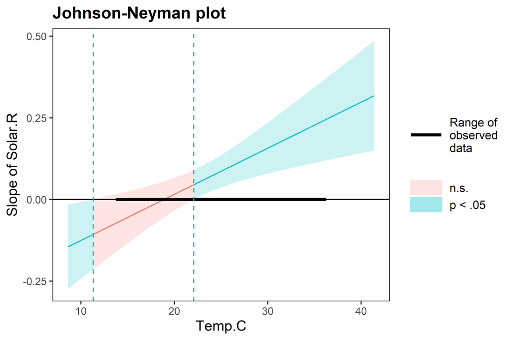

```r
P$results[[1]]$jn[[1]]$plot
```

# 模型诊断

#### 【知识点】回归模型的基本假定

回归模型的基本假定（basic assumptions）

- 线性关系（linearity）
- 残差独立（independence）
- 残差正态分布（normality）
- 残差方差齐性（homoscedasticity）
- 不存在多重共线性（no multicollinearity）

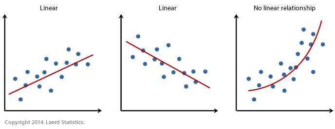

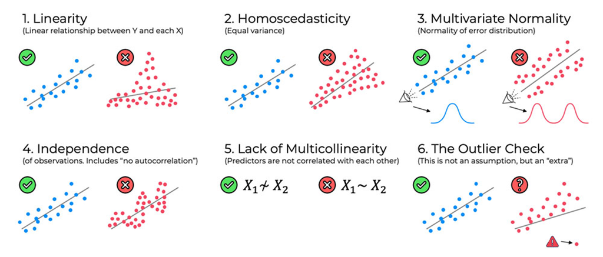

#### 【实践9】检查回归模型是否满足基本假定

- 使用`performance`包的`check_*()`系列函数（`bruceR`包已加载`performance`包）

```r
model = lm(Ozone ~ ., data=airquality)

check_model(model)  # 一次性检查所有假定
```

[figure not shown]

```r
check_outliers(model)  # 极端值问题
```

```
OK: No outliers detected.
- Based on the following method and threshold: cook (0.9).
- For variable: (Whole model)
```

```r
check_normality(model)  # 非正态问题
check_heteroscedasticity(model)  # 异方差问题
check_autocorrelation(model)  # 自相关问题
```

[output not shown]

```
OK: Residuals appear to be independent and not autocorrelated (p = 0.854).
```

```r
check_collinearity(model)  # 共线性问题
```

```
# Check for Multicollinearity

Low Correlation

    Term  VIF       VIF 95% CI adj. VIF Tolerance Tolerance 95% CI
 Solar.R 1.15 [1.03,     1.66]     1.07      0.87     [0.60, 0.97]
    Wind 1.33 [1.14,     1.78]     1.15      0.75     [0.56, 0.88]
    Temp 1.72 [1.40,     2.29]     1.31      0.58     [0.44, 0.71]
   Month 1.26 [1.09,     1.71]     1.12      0.80     [0.59, 0.91]
     Day 1.01 [1.00, 83489.99]     1.01      0.99     [0.00, 1.00]
```

# * 拓展：其他回归模型

#### 【探索发现】各类回归模型使用的R函数

- **一般线性模型**
  - `lm()`函数：OLS回归（连续因变量）
- **广义线性模型**
  - `glm()`函数
    - Logistic回归（二分类因变量）：`glm(..., data, family=binomial)`
    - Poisson回归（计数因变量）：`glm(..., data, family=poisson)`

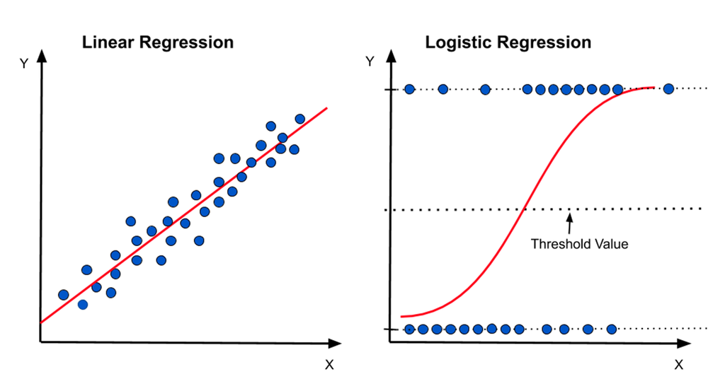

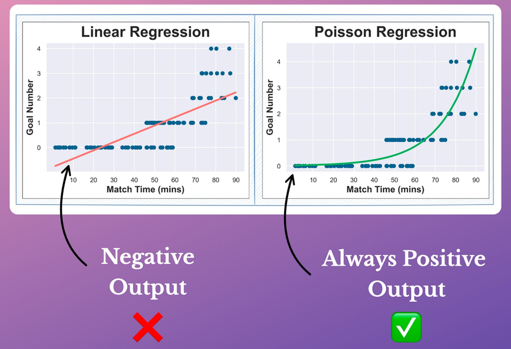

- **多分类因变量回归模型**
  - `nnet::multinom()`函数：Multinomial Log-Linear回归（多分类因变量）
- **线性混合模型（多水平模型）**
  - `nlme::lme()`函数
  - `lme4::lmer()`、`lmerTest::lmer()`函数
- **广义线性混合模型**
  - `nlme::nlme()`函数
  - `lme4::glmer()`函数

（多水平模型/线性混合模型的原理与方法，将在研究生阶段系统学习）

# 【阶段作业②】统计分析综合

作业要求：

- 基于期末自选数据和所有代码积累，综合运用第7章（基础统计）、第8章（方差分析）、第9章（回归分析）所学的统计方法和代码，自由分析你的期末自选数据，体现对R语言统计分析代码的掌握和迁移应用（7/8/9每章至少有一种方法体现在作业中）
- 使用R Markdown完成，对关键代码及结果要有注释说明

平台提交：

- 运行得到的HTML网页文件（本地的“.html”后缀格式文件）
  - 提交文件命名格式：`学号-姓名-R阶段作业2.html`

[返回课程主页](https://psychbruce.github.io/RCourse/)

© 包寒吴霜